# Start with Python - Practical exercise

# 1

```python
# do not forget to load necessary packages
import numpy as np
import pandas as pd
# please be aware that the import of pandas and other relevant packages was done here and I do not need to import it again below
```

## 1.1

Write a function that takes two predefined lists:

- list of weights:w
- list of heights: h

and converts it to dataframe. Add appropriate names for each columns of created dataframe.

```python
# predefined lists
w = [20, 30, 40, 50, 60, 70, 80]
h = [120, 130, 140, 150, 160, 170, 180]
```

```python
# your code
df = pd.DataFrame({"width":w, "height": h} )
df
```

|  | width | height |
| --- | --- | --- |
| 0 | 20 | 120 |
| 1 | 30 | 130 |
| 2 | 40 | 140 |
| 3 | 50 | 150 |
| 4 | 60 | 160 |
| 5 | 70 | 170 |
| 6 | 80 | 180 |

# 2

## 2.1

Write a function to create and display a DataFrame from a specified dictionary data (exam_data)

Resulting dataframe index will be given by a list of labels

exam_data = {} # enter your data acording to labels length

labels = ['a', 'b', 'c', 'd']

```python
labels = ['a', 'b', 'c', 'd','e','f','g','h','i']
# fill the data into this dictionary,  enter your data acording to labels length
exam_data  = {
  'name': ["Pascal","Alpha", "Beta", "Gamma","Delta","Eta","Omega","Sigma","Theta"],
  'score': np.random.randint(1,50,9),
  'attempts': [3,6,4,2,3,2,5,1,4 ],
  'qualify': [ 1,0,1,1,0,1,1,1,0]}
# your code
def convert_DataFrame(dictionary_list, label_list) -> pd.DataFrame:
    df = pd.DataFrame(dictionary_list, index=label_list)
    return df

df = convert_DataFrame(exam_data,labels)
```

## 2.2

Write a function to select the specified columns and rows from previously created DataFrame.

```python
# your code
df.loc[list(['b','d','g']),['name','score']]
```

|  | name | score |
| --- | --- | --- |
| b | Alpha | 22 |
| d | Gamma | 40 |
| g | Omega | 5 |

## 2.3

Then write a function to select the rows from previously created dataframe, where the score is between 15 and 20 (inclusive).

hint: pandas has between() method

```python
# your code
def select_range(df, column, rangeminmax):
    return df[df[column].between(rangeminmax[0],rangeminmax[1])]

print(select_range(df,"score",(15,20)))
```

```
Empty DataFrame
Columns: [name, score, attempts, qualify]
Index: []
```

# 3

## 3.1

Write a code (function is optional) to append a new row indexed as 'new_row' to previous dataframe and give values to each column that exists in it

Then delete the new row and return the changed and original dataframe.

```python
# your code
def addrow(df,new_row):
    df.loc[new_row] = ['New Person', 18, 1, 0]
    return df

print(addrow(df,'z'))
```

```
         name  score  attempts  qualify
a      Pascal      3         3        1
b       Alpha     22         6        0
c        Beta     35         4        1
d       Gamma     40         2        1
e       Delta     21         3        0
f         Eta     40         2        1
g       Omega      5         5        1
h       Sigma     31         1        1
i       Theta     31         4        0
z  New Person     18         1        0
```

## 3.2

Write a function to insert a new column in existing DataFrame

```python
# your code
def addcolumn(df,column_name):
    df[column_name] =np.nan
    return df

print(addcolumn(df,"NewCol"))
```

```
         name  score  attempts  qualify  NewCol
a      Pascal      3         3        1     NaN
b       Alpha     22         6        0     NaN
c        Beta     35         4        1     NaN
d       Gamma     40         2        1     NaN
e       Delta     21         3        0     NaN
f         Eta     40         2        1     NaN
g       Omega      5         5        1     NaN
h       Sigma     31         1        1     NaN
i       Theta     31         4        0     NaN
z  New Person     18         1        0     NaN
```

# 4

Write a function to count city wise number of people from a given data set (city, name of the person).

```python
df = pd.DataFrame({
    'name': ['Anastasia', 'Dima', 'Katherine', 'James', 'Emily', 'Michael', 'Matthew', 'Laura', 'Kevin', 'Jonas'],
    'city': ['California', 'Los Angeles', 'California', 'California', 'California', 'Los Angeles', 'Los Angeles', 'Georgia', 'Georgia', 'Los Angeles']
    })
# your code
def aggrdf(df,groups, aggr_dict):
    return df.groupby(groups).agg(aggr_dict)

print(aggrdf(df,["city"],{'name' : ['count']}))
```

```
             name
            count
city
California      4
Georgia         2
Los Angeles     4
```

# 5

## 5.1

Display the default index and set a column as an index in a given dataframe.

```python
df = pd.DataFrame({
    'school_code': ['s001','s002','s003','s001','s002','s004'],
    'class': ['V', 'V', 'VI', 'VI', 'V', 'VI'],
    'name': ['Alberto Franco','Gino Mcneill','Ryan Parkes', 'Eesha Hinton', 'Gino Mcneill', 'David Parkes'],
    'date_Of_Birth': ['15/05/2002','17/05/2002','16/02/1999','25/09/1998','11/05/2002','15/09/1997'],
    'weight': [35, 32, 33, 30, 31, 32],
    'address': ['street1', 'street2', 'street3', 'street1', 'street2', 'street4'],
    't_id':['t1', 't2', 't3', 't4', 't5', 't6']
    })
# your code

df.index
df1= df.set_index("t_id")
df1
```

| t_id | school_code | class | name | date_Of_Birth | weight | address |
| --- | --- | --- | --- | --- | --- | --- |
| t1 | s001 | V | Alberto Franco | 15/05/2002 | 35 | street1 |
| t2 | s002 | V | Gino Mcneill | 17/05/2002 | 32 | street2 |
| t3 | s003 | VI | Ryan Parkes | 16/02/1999 | 33 | street3 |
| t4 | s001 | VI | Eesha Hinton | 25/09/1998 | 30 | street1 |
| t5 | s002 | V | Gino Mcneill | 11/05/2002 | 31 | street2 |
| t6 | s004 | VI | David Parkes | 15/09/1997 | 32 | street4 |

## 5.2

Create a multi-index dataframe using two columns and using an index and a selected column.

Then convert index back to column.

```python
# your code
df = pd.DataFrame({
    'school_code': ['s001','s002','s003','s001','s002','s004'],
    'class': ['V', 'V', 'VI', 'VI', 'V', 'VI'],
    'name': ['Alberto Franco','Gino Mcneill','Ryan Parkes', 'Eesha Hinton', 'Gino Mcneill', 'David Parkes'],
    'date_Of_Birth': ['15/05/2002','17/05/2002','16/02/1999','25/09/1998','11/05/2002','15/09/1997'],
    'weight': [35, 32, 33, 30, 31, 32],
    'address': ['street1', 'street2', 'street3', 'street1', 'street2', 'street4'],
    't_id':['t1', 't2', 't3', 't4', 't5', 't6']
    })

df1=df.set_index(['t_id','school_code'])
print(df1)
df2= df.set_index([df.index,'t_id'])
print(df2)

df3=df1.reset_index()
print(df3)

df4=df2.reset_index().drop(columns="level_0")
print(df4)
```

```
                 class            name date_Of_Birth  weight  address
t_id school_code
t1   s001            V  Alberto Franco    15/05/2002      35  street1
t2   s002            V    Gino Mcneill    17/05/2002      32  street2
t3   s003           VI     Ryan Parkes    16/02/1999      33  street3
t4   s001           VI    Eesha Hinton    25/09/1998      30  street1
t5   s002            V    Gino Mcneill    11/05/2002      31  street2
t6   s004           VI    David Parkes    15/09/1997      32  street4
       school_code class            name date_Of_Birth  weight  address
  t_id
0 t1          s001     V  Alberto Franco    15/05/2002      35  street1
1 t2          s002     V    Gino Mcneill    17/05/2002      32  street2
2 t3          s003    VI     Ryan Parkes    16/02/1999      33  street3
3 t4          s001    VI    Eesha Hinton    25/09/1998      30  street1
4 t5          s002     V    Gino Mcneill    11/05/2002      31  street2
5 t6          s004    VI    David Parkes    15/09/1997      32  street4
  t_id school_code class            name date_Of_Birth  weight  address
0   t1        s001     V  Alberto Franco    15/05/2002      35  street1
1   t2        s002     V    Gino Mcneill    17/05/2002      32  street2
2   t3        s003    VI     Ryan Parkes    16/02/1999      33  street3
3   t4        s001    VI    Eesha Hinton    25/09/1998      30  street1
4   t5        s002     V    Gino Mcneill    11/05/2002      31  street2
5   t6        s004    VI    David Parkes    15/09/1997      32  street4
  t_id school_code class            name date_Of_Birth  weight  address
0   t1        s001     V  Alberto Franco    15/05/2002      35  street1
1   t2        s002     V    Gino Mcneill    17/05/2002      32  street2
2   t3        s003    VI     Ryan Parkes    16/02/1999      33  street3
3   t4        s001    VI    Eesha Hinton    25/09/1998      30  street1
4   t5        s002     V    Gino Mcneill    11/05/2002      31  street2
5   t6        s004    VI    David Parkes    15/09/1997      32  street4
```

### 6

Write a function to find the indexes of rows of a specified value of a given column in a dataFrame

```python
# your code
def find_ind(df, row_value, col):
  ind = df.index[df[col]==row_value].tolist()
  return ind

find_ind(df, 's001', 'school_code')
```

```
[0, 3]
```

### 7

Create a time series object that has time indexed data. Write a function to select the dates of same year and select the dates between certain dates

hint: methods: DatetimeIndex()

```python
# your code
index=pd.DatetimeIndex(["2026-01-01","2026-01-02","2026-01-03","2026-01-04","2026-01-05","2026-01-06","2026-01-07"])

date_series=pd.Series([1,2,3,4,5,6,7],index=index)
#s_dates = s_dates.sort_index() # no warning?
print(date_series)

print("\nDates of same year:")
print(date_series['2026'])

print("\nDates between 2012-01-03 and 2012-01-05")
print(date_series['2026-01-03':'2026-01-05'])
```

[output not shown]

### 8

Write a function to check whather a day is a business day (weekday) or not.

Hint: Check pandas time series functionality of bdate_range

```python
import datetime
# your code
def isbusinessday(date: datetime.date):
    return len(pd.bdate_range(date,date)) #nothing vs something, instead of 1/0 so unintuitive!
print(isbusinessday("2026-01-04"))
```

```
0
```

## 9

Write a function to create a period index representing all monthly boundaries of a given year. Also print start and end time for each period object (i.e month) in the said index.

hint: period_range,

- check differences between datetimeindex and periodindex of pandas time series objects
- Each record in a datetimeindex is a pd.Timestamp and represents a single point in time. Each record in a periodindex is a pd.Period and represents a time interval. A period contains a start_time and end_time attribute. They contain a lot of similar methods/attributes, and are often used interchangeably though.

```python
# your code
def getmonths(dtstart,dtend):
    all_months = pd.period_range(pd.to_datetime(dtstart),pd.to_datetime(dtend),freq="M")
    return all_months

def getstartenddates(monthlist):
    startenddates=[]
    for e in monthlist:
        startenddates.append(e.start_time)
        startenddates.append(e.end_time)
    return startenddates

print(getstartenddates(getmonths("2026-01-01","2026-12-31")))
```

[output not shown]

## 10

Write function to split the given dataframe into groups based on school code. Also check the type of GroupBy object.

```python
student_data = pd.DataFrame({
    'school_code': ['s001','s002','s003','s001','s002','s004'],
    'class': ['V', 'V', 'VI', 'VI', 'V', 'VI'],
    'name': ['Alberto Franco','Gino Mcneill','Ryan Parkes', 'Eesha Hinton', 'Gino Mcneill', 'David Parkes'],
    'date_Of_Birth ': ['15/05/2002','17/05/2002','16/02/1999','25/09/1998','11/05/2002','15/09/1997'],
    'age': [12, 12, 13, 13, 14, 12],
    'height': [173, 192, 186, 167, 151, 159],
    'weight': [35, 32, 33, 30, 31, 32],
    'address': ['street1', 'street2', 'street3', 'street1', 'street2', 'street4']},
    index=['S1', 'S2', 'S3', 'S4', 'S5', 'S6'])
# your code

def splitgroup(df:pd.DataFrame,splitcolumns:str):
    df1 = df.groupby([splitcolumns])
    return df1

for name,group in splitgroup(student_data,"school_code"):
    print(f"{name} : ")
    print(group)

print("\nType of the object:")
print(type(group))
```

```
('s001',) :
   school_code class            name date_Of_Birth   age  height  weight  \
S1        s001     V  Alberto Franco     15/05/2002   12     173      35
S4        s001    VI    Eesha Hinton     25/09/1998   13     167      30

    address
S1  street1
S4  street1
('s002',) :
   school_code class          name date_Of_Birth   age  height  weight  \
S2        s002     V  Gino Mcneill     17/05/2002   12     192      32
S5        s002     V  Gino Mcneill     11/05/2002   14     151      31

    address
S2  street2
S5  street2
('s003',) :
   school_code class         name date_Of_Birth   age  height  weight  address
S3        s003    VI  Ryan Parkes     16/02/1999   13     186      33  street3
('s004',) :
   school_code class          name date_Of_Birth   age  height  weight  \
S6        s004    VI  David Parkes     15/09/1997   12     159      32

    address
S6  street4

Type of the object:
<class 'pandas.core.frame.DataFrame'>
```

### Group Work

- Import dataset of your choice and convert it to dataframe, including proper columns naming.
- Import dataset of your choice and convert it to dataframe, including proper columns naming.
- Explore groupby function of pandas print mean values for selected groups and plot distribution of data in selected groups
- Depending on the data you selected:
  - apply one-hot/dummy encoding on selected feature
  - apply scaling of selected features
  - select k best features based on Chi2 test

Bonus:

- apply recursive feature selection using
  - from sklearn.feature_selection import RFE
- compare features selected by both methods

```python
# your code
import os
# Constants
global WORKING_DIRECTORY

# Get the current working directory
cwd = os.getcwd()
WORKING_DIRECTORY = os.path.dirname(os.path.dirname(cwd)) #Parent directory

print("The current working directory is:", WORKING_DIRECTORY)

DATA_DIRECTORY = os.path.join(WORKING_DIRECTORY,"Project\\Data")
print("The data directory is:", DATA_DIRECTORY)

RAW_Data_DIR=  os.path.join(DATA_DIRECTORY,"01-raw")
PREPROCESS_Data_DIR=  os.path.join(DATA_DIRECTORY,"02-preprocessed")
FEATURES_Data_DIR=  os.path.join(DATA_DIRECTORY,"03-features")
PREDICTIONS_Data_DIR=  os.path.join(DATA_DIRECTORY,"04-predictions")

#import previous modules output
ts_df= pd.read_pickle(os.path.join(RAW_Data_DIR,"timeseries_data.pkl"))
exercise_df = pd.read_pickle(os.path.join(RAW_Data_DIR,"exercise_data.pkl"))
training_df= pd.read_pickle(os.path.join(RAW_Data_DIR,"training_data.pkl"))
mw_detecxtions=pd.read_pickle(os.path.join(RAW_Data_DIR,"moving_window_detections.pkl"))
peaks_df = pd.read_pickle(os.path.join(RAW_Data_DIR,"peaks.pkl"))
valleys_df=pd.read_pickle(os.path.join(RAW_Data_DIR,"valleys.pkl"))
```

```
The current working directory is: h:\Documents\My Training\CAS\CAS_DLS\0_Module\M3_Machine_Learning
The data directory is: h:\Documents\My Training\CAS\CAS_DLS\0_Module\M3_Machine_Learning\Project\Data
```

## Homework

Write a function to apply log and box-cox transformation. Select a adataset, convert it to pandas dataframe, select feature, display its histogram before transformation, and then after both transformations.

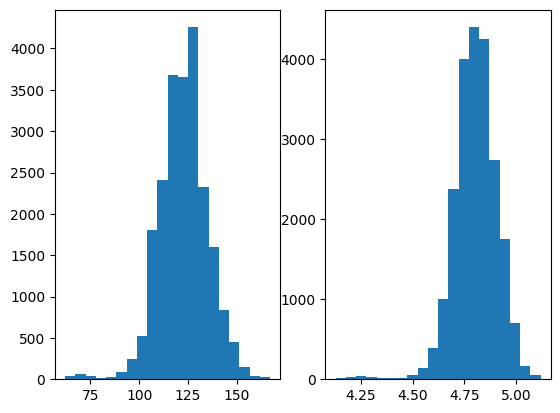

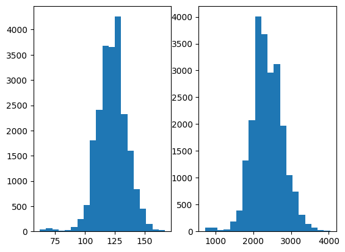

```python
# your code
import matplotlib.pyplot as plt
from scipy.stats import boxcox
X = ts_df["5SHR"].dropna()
X_log = np.log(X)

fig,(ax1, ax2) = plt.subplots(1,2)
ax1.hist(X,bins=20)
ax2.hist(X_log,bins=20)

# box_cox
from scipy.stats import boxcox
X_bc, best_lambda = boxcox(X)
fig,(ax1, ax2) = plt.subplots(1,2)
ax1.hist(X,bins=20)
ax2.hist(X_bc,bins=20)
```

```python
# convert colab nb to html
%%shell jupyter-nbconvert --to html "0_Module\M3_Machine_Learning\Notebooks\W1\W1-Exercises.ipynb"
```

```
UsageError: Line magic function `%%shell` not found.
```